Saltar al contenido principal

dgtrabada

- .rst

# Cuestionario puertas lógicas

# Cuestionario puertas lógicas

En las preguntas, a̅ es la negación de a (NOT a), * es AND, + es OR y ⊗ es XOR.

AND OR NAND

OR NOR XOR

OR NOR XOR

AND NAND NOT

OR XOR AND

NAND NOR NOT

7. ¿Qué indica el círculo pequeño a la salida de algunas puertas (NAND, NOR, NOT)?

Que la salida está negada Que la puerta tiene tres entradas Que la salida vale siempre 1

2. Completa la tabla de verdad:

| a | b | a*b (AND) | a+b (OR) | NAND | NOR | a⊗b (XOR) |
| --- | --- | --- | --- | --- | --- | --- |
| 0 | 0 |  |  |  |  |  |
| 0 | 1 |  |  |  |  |  |
| 1 | 0 |  |  |  |  |  |
| 1 | 1 |  |  |  |  |  |

3. Si a = 1, b = 0 y c = 1, ¿cuánto vale cada expresión?

1. a*b

Vale:

2. a+b

Vale:

3. a̅

Vale:

4. NOT (a*c)

Vale:

5. (a+b)*c

Vale:

6. a*b+c

Vale:

7. a⊗b

Vale:

8. a⊗b⊗c

Vale:

Salida:

Salida:

Salida:

Salida:

Salida:

Salida:

Salida:

Salida:

Salida:

Salida:

Salida:

5. Álgebra de Boole:

1. Según el teorema de Morgan, la negación de (a+b) es igual a:

a̅*b̅ a̅+b̅ a*b

2. Según el teorema de Morgan, la negación de (a*b) es igual a:

a̅*b̅ a̅+b̅ a+b

3. Una función vale 1 solo en las filas a=0, b=1 y a=1, b=0. Con la primera forma canónica (suma de productos), ¿cuál es su fórmula?

f = a̅b + ab̅ f = ab + a̅b̅ f = a̅b̅ + ab

4. ¿A qué puerta equivale la función de la pregunta anterior?

OR XOR NOR

5. Una función vale 1 en las filas 00, 01 y 10, y 0 en la fila 11. ¿A qué puerta equivale?

AND NOR NAND

6. ¿Se puede construir cualquier circuito lógico usando solo puertas NAND?

Sí No

7. Obtén la primera forma canónica (mintérminos) de la siguiente tabla de verdad:

| A | B | F |
| --- | --- | --- |
| 0 | 0 | 0 |
| 0 | 1 | 1 |
| 1 | 0 | 0 |
| 1 | 1 | 0 |

F = A+B F = A̅+B F = A*B F = A̅*B

6. Se quiere diseñar el control de una puerta automática. La puerta se abre (S = 1) solo si hay una persona delante del sensor (P = 1) y, además, tiene una tarjeta válida (T = 1) o el guardia autoriza la entrada (G = 1). En cualquier otro caso la puerta sigue cerrada (S = 0).

1. Completa la tabla de verdad:

| P | T | G | S |
| --- | --- | --- | --- |
| 0 | 0 | 0 |  |
| 0 | 0 | 1 |  |
| 0 | 1 | 0 |  |
| 0 | 1 | 1 |  |
| 1 | 0 | 0 |  |
| 1 | 0 | 1 |  |
| 1 | 1 | 0 |  |
| 1 | 1 | 1 |  |

2. ¿Cuál es la función S?

S = P*(T+G) S = P*T*G S = P+T+G

3. El circuito tiene dos puertas: T y G entran en una puerta y su salida entra, junto con P, en una puerta AND. ¿Qué puerta es la primera?

7. Sumadores:

1. En el sumador de dos bits a y b, ¿qué puerta da la suma S?

AND OR XOR

2. En el sumador de dos bits, ¿qué puerta da el acarreo (cuando a y b valen 1)?

AND OR XOR

3. En el sumador de dos bits, si a = 1 y b = 1:

S = C<sub>+</sub> =

4. En el sumador con acarreo, si c = 1, a = 1 y b = 0:

S = C<sub>+</sub> =

5. En el sumador con acarreo, si c = 1, a = 1 y b = 1:

S = C<sub>+</sub> =

6. En el sumador con acarreo, si c = 0, a = 0 y b = 1:

S = C<sub>+</sub> =

7. ¿Cuál es la fórmula de la suma S en el sumador con acarreo?

S = a⊗b⊗c S = a*b*c S = a+b+c

8. Para sumar números de 8 bits, ¿cuántos sumadores con acarreo hay que encadenar?

8. Fíjate en el circuito del sumador con acarreo. Si a1 = 0, b1 = 0 y c1 = 0, entonces s1 = 0 y c1+ = 0. Completa la tabla:

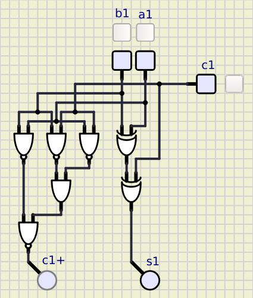

| c1 | b1 | a1 | s1 | c1+ |
| --- | --- | --- | --- | --- |
| 0 | 0 | 0 |  |  |
| 0 | 0 | 1 |  |  |
| 0 | 1 | 0 |  |  |
| 0 | 1 | 1 |  |  |
| 1 | 0 | 0 |  |  |
| 1 | 0 | 1 |  |  |
| 1 | 1 | 0 |  |  |
| 1 | 1 | 1 |  |  |

9. Circuitos combinacionales:

1. En un circuito combinacional, las salidas dependen:

Solo de los valores de las entradas en ese momento De las entradas y de los estados anteriores

2. ¿Cuántas salidas tiene un decodificador de 3 entradas?

3. ¿Cuántas salidas tiene un codificador de 16 entradas?

4. ¿Cuántas entradas de selección necesita un multiplexor de 8 entradas de información?

5. ¿Qué circuito activa la salida que corresponde al código binario presente en la entrada?

Decodificador Codificador Multiplexor

6. ¿Qué circuito elige cuál de sus entradas de información pasa a la salida?

Decodificador Codificador Multiplexor

10. Circuitos secuenciales:

1. En un circuito secuencial, las salidas dependen:

Solo de los valores de las entradas en ese momento De las entradas y de los estados anteriores

2. ¿Cómo se llaman los circuitos capaces de retener un bit de información?

Biestables Decodificadores Multiplexores

3. En un biestable RS, si R = 0 y S = 1, ¿cuánto vale Q?

4. En un biestable RS, si R = 1 y S = 0, ¿cuánto vale Q?

5. En un biestable RS, si R = 0 y S = 0:

Q mantiene el valor que tenía Q pasa a valer 0 Q pasa a valer 1

6. ¿Qué problema tiene el biestable RS cuando R = 1 y S = 1?

La salida no está definida La salida vale siempre 0 La salida vale siempre 1

7. ¿Qué hace el biestable JK cuando sus dos entradas valen 1?

Cambia de estado (Q pasa a valer lo contrario) Mantiene el estado Su salida no está definida

8. Un biestable T con T = 1 y Q = 0 recibe 3 pulsos de reloj. ¿Cuánto vale Q después?

9. ¿Qué biestables se usan para construir un registro?

RS T D

10. ¿Qué circuito presenta en binario el número de impulsos que han llegado a su entrada?

Registro Contador Decodificador